# Making nice tables with sparklines

Jean Clipperton

2025-02-20

## Starting with our data

```
## # A tibble: 72 × 3
##     year field                          pct
##    <dbl> <fct>                        <dbl>
##  1  1970 Business                    0.137
##  2  1970 Health professions          0.0300
##  3  1970 Social sciences and history 0.185
##  4  1970 Other                       0.648
##  5  1975 Business                    0.155
##  6  1975 Health professions          0.0582
##  7  1975 Social sciences and history 0.137
##  8  1975 Other                       0.651
##  9  1980 Business                    0.214
## 10  1980 Health professions          0.0681
## # ℹ 62 more rows
```

## Starting with a table

Let’s make this a little nicer – we’re going to do some formatting, variable naming, etc.

| Popular Bachelor's degrees over the years Year | Popular Bachelor's degrees over the years Business | Popular Bachelor's degrees over the years Health professions | Popular Bachelor's degrees over the years Social sciences and history | Popular Bachelor's degrees over the years Other |
| --- | --- | --- | --- | --- |
| 1970 | 13.7% | 3.0% | 18.5% | 64.8% |
| 1975 | 15.5% | 5.8% | 13.7% | 65.1% |
| 1980 | 21.4% | 6.8% | 10.7% | 61.0% |
| 1985 | 24.0% | 6.6% | 9.5% | 60.0% |
| 1990 | 22.8% | 5.4% | 11.4% | 60.4% |
| 1995 | 19.5% | 7.4% | 10.9% | 62.3% |
| 2000 | 21.2% | 6.1% | 10.3% | 62.5% |
| 2005 | 21.4% | 6.2% | 10.9% | 61.5% |
| 2012 | 19.6% | 9.8% | 9.7% | 60.9% |
| 2013 | 19.1% | 10.6% | 9.3% | 61.0% |
| 2014 | 19.2% | 11.4% | 8.8% | 60.6% |
| 2015 | 19.4% | 11.9% | 8.4% | 60.4% |
| 2016 | 19.5% | 12.1% | 8.1% | 60.3% |
| 2017 | 19.5% | 12.3% | 8.1% | 60.1% |
| 2018 | 19.4% | 12.5% | 8.0% | 60.2% |
| 2019 | 19.0% | 12.6% | 7.9% | 60.4% |
| 2020 | 18.9% | 13.0% | 7.8% | 60.3% |
| 2021 | 18.6% | 13.1% | 7.5% | 60.8% |

## Maybe a plot?

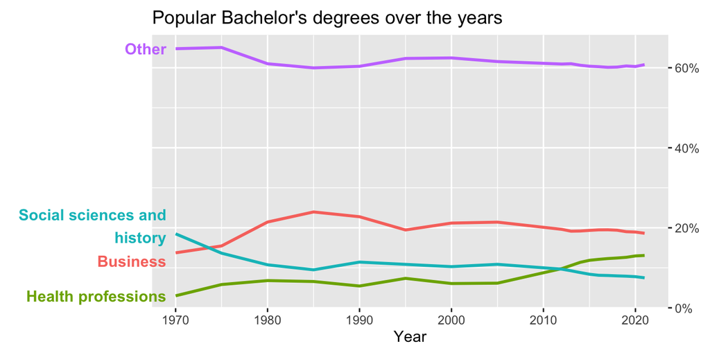

## Prep for both:

| Popular Bachelor's degrees over the years Field | Popular Bachelor's degrees over the years 1970 | Popular Bachelor's degrees over the years 1975 | Popular Bachelor's degrees over the years 1980 | Popular Bachelor's degrees over the years 1985 | Popular Bachelor's degrees over the years 1990 | Popular Bachelor's degrees over the years 1995 | Popular Bachelor's degrees over the years 2000 | Popular Bachelor's degrees over the years 2005 | Popular Bachelor's degrees over the years 2012 | Popular Bachelor's degrees over the years 2013 | Popular Bachelor's degrees over the years 2014 | Popular Bachelor's degrees over the years 2015 | Popular Bachelor's degrees over the years 2016 | Popular Bachelor's degrees over the years 2017 | Popular Bachelor's degrees over the years 2018 | Popular Bachelor's degrees over the years 2019 | Popular Bachelor's degrees over the years 2020 | Popular Bachelor's degrees over the years 2021 |
| --- | --- | --- | --- | --- | --- | --- | --- | --- | --- | --- | --- | --- | --- | --- | --- | --- | --- | --- |
| Business | 14% | 15% | 21% | 24% | 23% | 19% | 21% | 21% | 20% | 19% | 19% | 19% | 19% | 20% | 19% | 19% | 19% | 19% |
| Health professions | 3% | 6% | 7% | 7% | 5% | 7% | 6% | 6% | 10% | 11% | 11% | 12% | 12% | 12% | 12% | 13% | 13% | 13% |
| Social sciences and history | 18% | 14% | 11% | 9% | 11% | 11% | 10% | 11% | 10% | 9% | 9% | 8% | 8% | 8% | 8% | 8% | 8% | 7% |
| Other | 65% | 65% | 61% | 60% | 60% | 62% | 62% | 62% | 61% | 61% | 61% | 60% | 60% | 60% | 60% | 60% | 60% | 61% |

## Basic `gt` table with sparklines

field

ggplot

1970

1975

1980

1985

1990

1995

2000

2005

2012

2013

2014

2015

2016

2017

2018

2019

2020

2021

Business

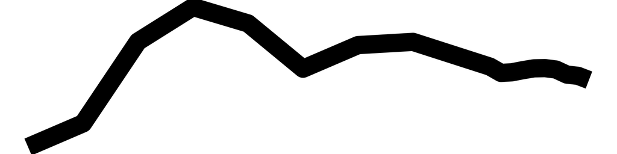

0.13742036

0.15465473

0.21442886

0.23961783

0.22764399

0.19456092

0.21179966

0.2141554

0.19609363

0.19149908

0.19195090

0.19351295

0.19482965

0.19500521

0.19397582

0.19026067

0.1893825

0.18630843

Health professions

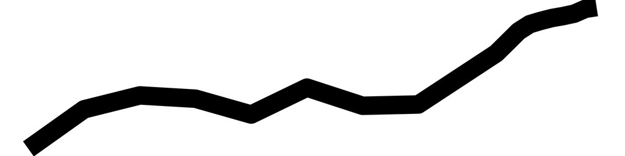

0.03003465

0.05820711

0.06808072

0.06574153

0.05448509

0.07362259

0.06071272

0.0616307

0.09804329

0.10584659

0.11371057

0.11874268

0.12112331

0.12312834

0.12451033

0.12622224

0.1296868

0.13089847

Social sciences and history

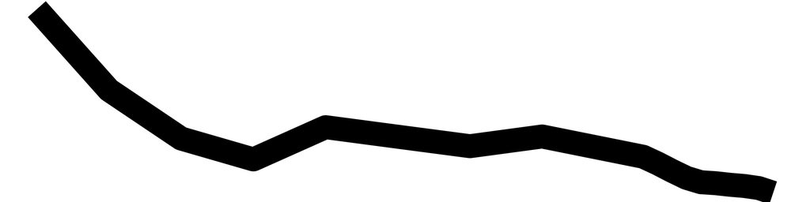

0.18496898

0.13653421

0.10748444

0.09499678

0.11430119

0.10858505

0.10290868

0.1087250

0.09659250

0.09257653

0.08811279

0.08393128

0.08133319

0.08076176

0.07981676

0.07908001

0.0778388

0.07499076

Other

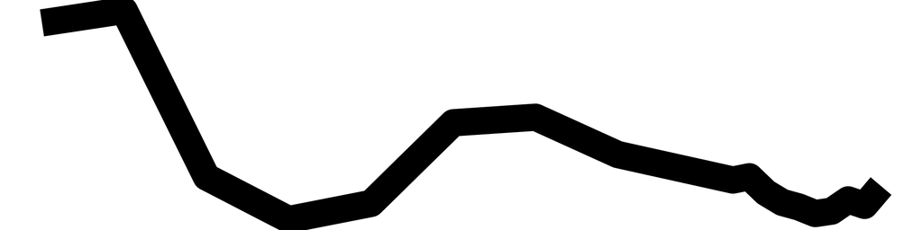

0.64757601

0.65060395

0.61000599

0.59964386

0.60356973

0.62323144

0.62457894

0.6154889

0.60927058

0.61007780

0.60622575

0.60381309

0.60271385

0.60110468

0.60169710

0.60443708

0.6030919

0.60780235

### Polishing it up!

Let’s turn this into something a little bit nicer. We can add color, turn decimals into percentages, and generally make it a little more professional.

Popular Bachelor's degrees over the years

Field

Trend

1970

1975

1980

1985

1990

1995

2000

2005

2012

2013

2014

2015

2016

2017

2018

2019

2020

2021

Business

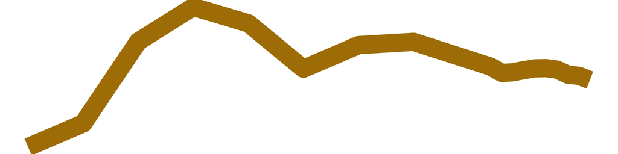

13.7%

15.5%

21.4%

24.0%

22.8%

19.5%

21.2%

21.4%

19.6%

19.1%

19.2%

19.4%

19.5%

19.5%

19.4%

19.0%

18.9%

18.6%

Health professions

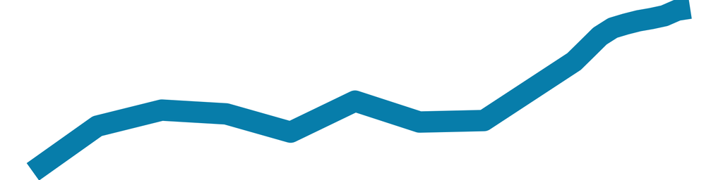

3.0%

5.8%

6.8%

6.6%

5.4%

7.4%

6.1%

6.2%

9.8%

10.6%

11.4%

11.9%

12.1%

12.3%

12.5%

12.6%

13.0%

13.1%

Social sciences and history

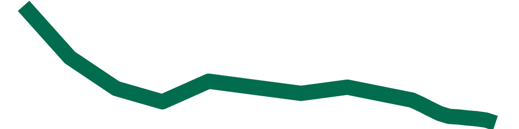

18.5%

13.7%

10.7%

9.5%

11.4%

10.9%

10.3%

10.9%

9.7%

9.3%

8.8%

8.4%

8.1%

8.1%

8.0%

7.9%

7.8%

7.5%

Other

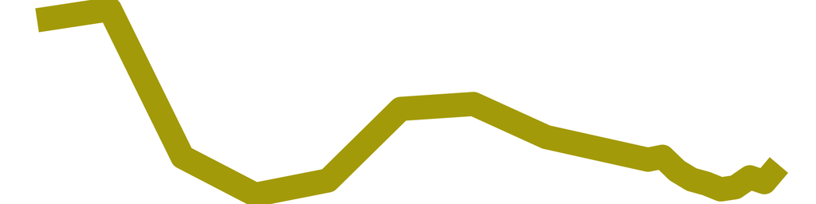

64.8%

65.1%

61.0%

60.0%

60.4%

62.3%

62.5%

61.5%

60.9%

61.0%

60.6%

60.4%

60.3%

60.1%

60.2%

60.4%

60.3%

60.8%

## Altering table style

Note that we can change what we want our plot to look like (also note that this particular plot choice revelals the timeframe of our data collectio/reporting).

Popular Bachelor's degrees over the years

Field

Trend

1970

1975

1980

1985

1990

1995

2000

2005

2012

2013

2014

2015

2016

2017

2018

2019

2020

2021

Business

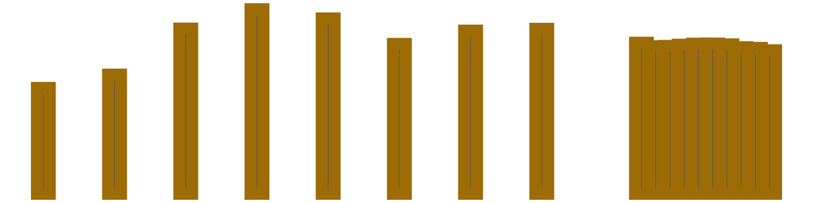

13.7%

15.5%

21.4%

24.0%

22.8%

19.5%

21.2%

21.4%

19.6%

19.1%

19.2%

19.4%

19.5%

19.5%

19.4%

19.0%

18.9%

18.6%

Health professions

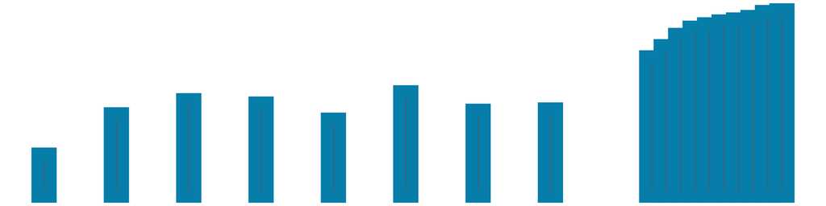

3.0%

5.8%

6.8%

6.6%

5.4%

7.4%

6.1%

6.2%

9.8%

10.6%

11.4%

11.9%

12.1%

12.3%

12.5%

12.6%

13.0%

13.1%

Social sciences and history

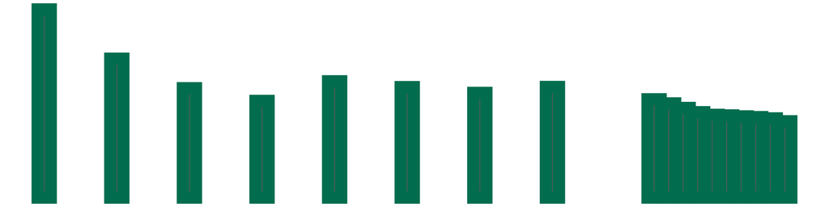

18.5%

13.7%

10.7%

9.5%

11.4%

10.9%

10.3%

10.9%

9.7%

9.3%

8.8%

8.4%

8.1%

8.1%

8.0%

7.9%

7.8%

7.5%

Other

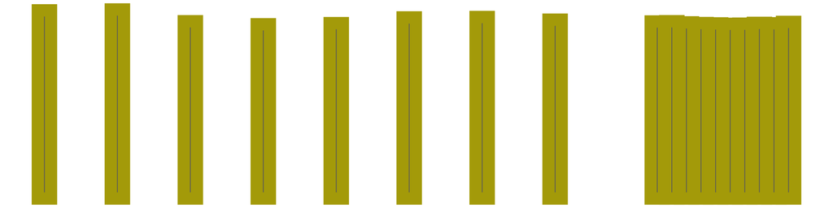

64.8%

65.1%

61.0%

60.0%

60.4%

62.3%

62.5%

61.5%

60.9%

61.0%

60.6%

60.4%

60.3%

60.1%

60.2%

60.4%

60.3%

60.8%